# SIS Ambiental: IA para o Licenciamento Ambiental

Eng. Civil e Ambiental · UFPB

[figure not shown]

Eufrásio de Andrade Lima Neto

Estatística · UFPB

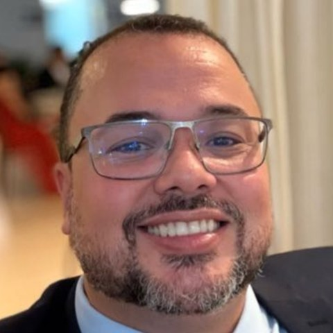

Hemílio Fernandes Campos Coêlho

Estatística · UFPB

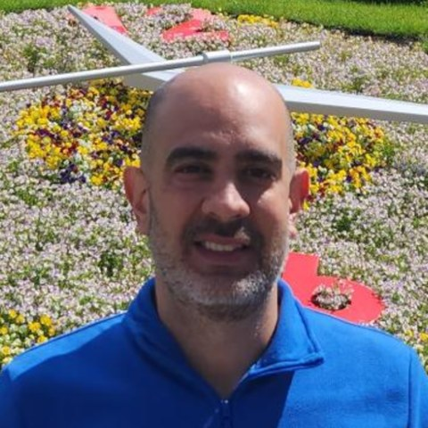

Luiz Medeiros de Araujo Lima Filho

Estatística · UFPB

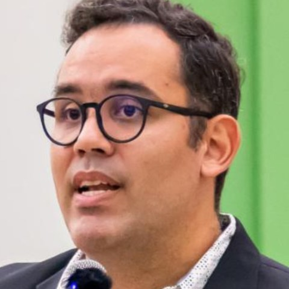

Yuri Wanderley Cavalcanti

PPGMDS · UFPB

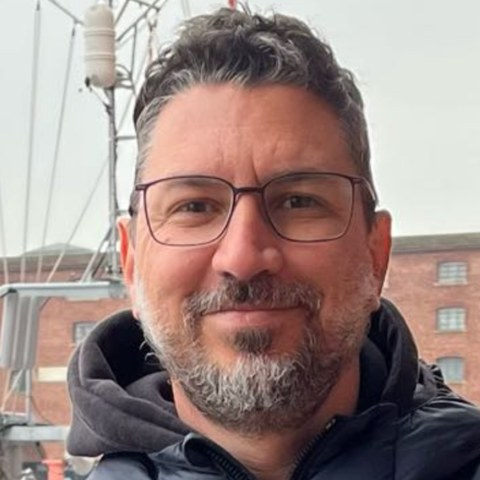

Rodrigo Bernardo da Silva

Estatística · UFPB

SIS Ambiental · INOVATEC-JP 007/2025 · UFPB

[figure not shown]

[figure not shown]

[figure not shown]

Universidade Federal da Paraíba

[figure not shown]

Departamento de Estatística

Obrigado

Licenciamento mais rápido, transparente e com menos idas a campo.

Coordenação: **Prof. Dr. Pedro Rafael Diniz Marinho** · pedro.rafael.marinho@gmail.com Apresentação: **Prof. Dr. Joácio de Araújo Morais Júnior**